# Homework Two

Alicia Kincaid

## Question One

### i)

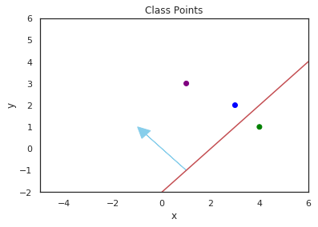

```python
x_values = np.linspace(-1, 6, 100)
first_line = x_values - 2

weight_value1 = np.array([-1, 1])
origin_value1 = np.array([1, -1])

plot_perceptron(first_line, weight_value1, origin_value1, '-r')
```

### ii)

$\vec{w}(0) \cdot \vec{x_1} = \begin{bmatrix} 2\\ -1\\1 \end{bmatrix} \begin{bmatrix} 1\\ 1\\3 \end{bmatrix} = 2 - 1 + 3 = 4 > 0$ Thus, correctly classified

$\vec{w}(0) \cdot \vec{x_2} = \begin{bmatrix} 2\\ -1\\1 \end{bmatrix} \begin{bmatrix} 1\\ 3\\2 \end{bmatrix} = 2 - 3 + 2 = 1 > 0$ Thus, incorrectly classified

$\vec{w}(0) \cdot \vec{x_1} = \begin{bmatrix} 2\\ -1\\1 \end{bmatrix} \begin{bmatrix} 1\\ 4\\1 \end{bmatrix} = 2 - 4 + 1 = -1 < 0$ Thus, correctly classified

### iii)

$\vec{w}(1) = \vec{w}(0) - \vec{x_2} = \begin{bmatrix} 2\\ -1\\1 \end{bmatrix} -\begin{bmatrix} 1\\ 3\\2 \end{bmatrix} = \begin{bmatrix} 1\\ -4\\-1 \end{bmatrix}$

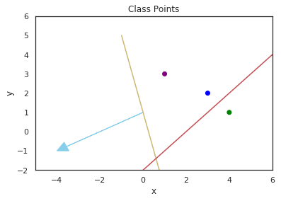

```python
x_values = np.linspace(-1, 6, 100)
second_line = -4*x_values + 1

weight_value2 = np.array([-4, -1])
origin_value2 = np.array([0, 1])

plot_perceptron(second_line, weight_value2, origin_value2, '-y', first_line, '-r')
```

$\vec{w}(1) \cdot \vec{x_1} = \begin{bmatrix} 1\\ -4\\-1 \end{bmatrix} \begin{bmatrix} 1\\ 1\\3 \end{bmatrix} = 1 - 4 - 3 = -6 < 0$ Thus, incorrectly classified

$\vec{w}(1) \cdot \vec{x_2} = \begin{bmatrix} 1\\ -4\\-1 \end{bmatrix} \begin{bmatrix} 1\\ 3\\2 \end{bmatrix} = 1 - 12 - 2 = -13 < 0$ Thus, correctly classified

$\vec{w}(1) \cdot \vec{x_1} = \begin{bmatrix} 1\\ -4\\-1 \end{bmatrix} \begin{bmatrix} 1\\ 4\\1 \end{bmatrix} = 1 - 16 - 1 = -16 < 0$ Thus, correctly classified

### iv)

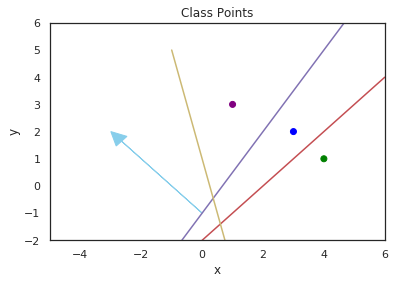

```python
x_values = np.linspace(-1, 6, 100)
third_line = (3/2)*x_values - 1

weight_value3 = np.array([-3, 2])
origin_value3 = np.array([0, -1])

plot_perceptron(third_line, weight_value3, origin_value3, \
                '-m', first_line, '-r', second_line, '-y')
```

## Question Two

### i)

I was not able to get my training data's 'scaled sound pressure level' to graph so I instead displayed the testing data's values. This output is more normally distributed.

```
21
```

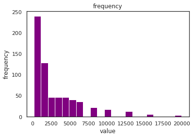

```
14
```

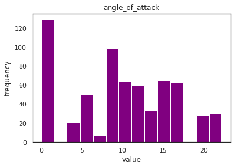

```
4
```

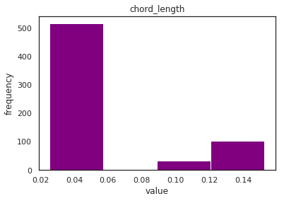

```
4
```

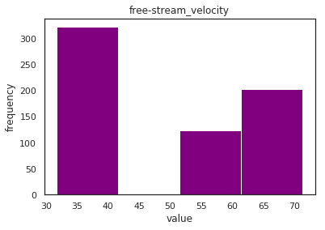

```
48
```

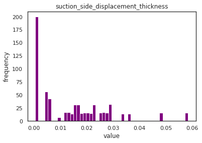

```
638
```

[figure not shown]

```python
loop_through_columns(train_data)
```

I was unable to get scaled sound pressure to print for my training data, so I decided to display the data from my test set.

This appears to have a more uniform distribution

```
149
```

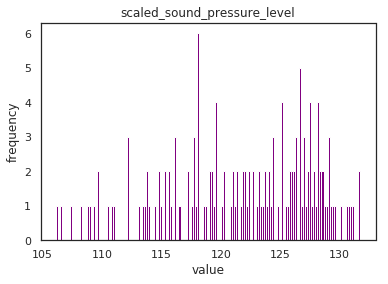

```python
create_histogram(test_data, 'scaled_sound_pressure_level')
```

### ii)

This model has 6 parameters including the intercept.

```python
train_data['intercept'] = pd.Series(np.array([1]*train_data.shape[0]),\
                                    index=train_data.index)
X = train_data.loc[:, train_data.columns != 'scaled_sound_pressure_level'].values
y = train_data.scaled_sound_pressure_level.values
```

```python
weights = np.linalg.inv(X.T @ X) @ X.T @ y
```

```python
weights
```

```
array([-7.11322380e-04, -4.54774159e-01, -5.23017057e+01,  8.39826774e-02,
       -9.14287813e+01,  1.32303685e+02])
```

```python
y_hat = X @ weights

rss = (y - y_hat).T @ (y - y_hat)
```

```python
rss
```

```
18033.325499244576
```

### iii)

The RSS value is 5136

```python
test_data['intercept'] = pd.Series(np.array([1]*test_data.shape[0]), \
                                   index=test_data.index)
X = test_data.loc[:, test_data.columns != 'scaled_sound_pressure_level'].values
y = test_data.scaled_sound_pressure_level.values
```

```python
y_hat = X @ weights
```

```python
rss = (y - y_hat).T @ (y - y_hat)
```

```python
rss
```

```
5136.396371518451
```

### iv)

These rss values are definitely incorrect. I did not give myself enough time to complete this section.

```python
loop_through_columns_2(test_data)
```

```
RSS =  1102.4333446950402  when  frequency  removed
RSS =  1102.4333446950402  when  angle_of_attack  removed
RSS =  1102.4333446950402  when  chord_length  removed
RSS =  1102.4333446950402  when  free-stream_velocity  removed
RSS =  1102.4333446950402  when  suction_side_displacement_thickness  removed
```

```python
import matplotlib.pyplot as plt
import seaborn as sns
sns.set(style="white")
import pandas as pd
import numpy as np
import random
import math
import csv
```

### Functions for Question 1

```python
def plot_perceptron(line, weight_value, origin_value, line_color, \
                    other_line1 = None, line_color2 = None,\
                    other_line2 = None, line_color3 = None):
    x_coordinates = np.array([1, 3, 4])
    y_coordinates = np.array([3, 2, 1])
    x_values = np.linspace(-1, 6, 100)
    axes = plt.gca()
    axes.set_xlim([-5, 6])
    axes.set_ylim(-2, 6)
    plt.title("Class Points")
    plt.xlabel("x")
    plt.ylabel("y")

    plt.plot(x_values, line, line_color)
    plt.scatter(x_coordinates, y_coordinates, color=["purple", "blue", "green"])
    drawArrow(origin_value, weight_value)

    if line_color2 != None:
        plt.plot(x_values, other_line1, line_color2)
    if line_color3 != None:
        plt.plot(x_values, other_line2, line_color3)

def drawArrow(A, B):
    color = 'skyblue'
    plt.arrow(A[0], A[1], B[0] - A[0], B[1] - A[1], head_width=0.5, \
              head_length=0.5, fc=color, ec=color, length_includes_head = True)
```

## Functions For Question 2

```python
column_titles = ['frequency', 'angle_of_attack', 'chord_length', 'free-stream_velocity',\
                'suction_side_displacement_thickness', 'scaled_sound_pressure_level']

train_data = pd.read_csv('airfoil_self_noise_train.csv', names=column_titles)
test_data = pd.read_csv('airfoil_self_noise_test.csv', names=column_titles)

#Plots the histogram
def create_histogram(input_data, column_name):
    list_to_plot = input_data[column_name].tolist()
    #print(list_to_plot)
    size = len(set(list_to_plot))
    print(size)
    plt.title(column_name)
    plt.ylabel('frequency')
    plt.xlabel('value')
    plt.hist(list_to_plot, size, color="purple")
    plt.show()


#Accesses each column (except class) to call the histogram function
def loop_through_columns(input_data):
    for column_title in column_titles:
        create_histogram(input_data, column_title)

def loop_through_columns_2(input_data):
    for column_title in column_titles:
        if column_title != 'scaled_sound_pressure_level':
            removing_features(input_data, column_title)

def removing_features(input_data, column_name):
    input_data['intercept'] = pd.Series(np.array([1]*input_data.shape[0]),\
                                        index=input_data.index)
    input_data.drop(columns=[column_name])
    X = input_data.loc[:, input_data.columns != 'scaled_sound_pressure_level'].values
    y = input_data.scaled_sound_pressure_level.values
    weights = np.linalg.inv(X.T @ X) @ X.T @ y
    y_hat = X @ weights
    rss = (y - y_hat).T @ (y - y_hat)
    print("RSS = ", rss, " when ", column_name, " removed")
```